# Business_Forecasting

**Naïve Method** Using Naive method to forecast

```r
naive_ts<-naive(NITS)
naive_ts
```

```
##         Point Forecast    Lo 80    Hi 80    Lo 95    Hi 95
## 2018 Q1         3021.6 2881.007 3162.193 2806.581 3236.619
## 2018 Q2         3021.6 2822.771 3220.429 2717.518 3325.682
## 2018 Q3         3021.6 2778.086 3265.114 2649.177 3394.023
## 2018 Q4         3021.6 2740.414 3302.786 2591.563 3451.637
## 2019 Q1         3021.6 2707.224 3335.976 2540.804 3502.396
## 2019 Q2         3021.6 2677.219 3365.981 2494.914 3548.286
## 2019 Q3         3021.6 2649.626 3393.574 2452.714 3590.486
## 2019 Q4         3021.6 2623.943 3419.257 2413.436 3629.764
## 2020 Q1         3021.6 2599.821 3443.379 2376.544 3666.656
## 2020 Q2         3021.6 2577.006 3466.194 2341.651 3701.549
```

. Perform Residual Analysis for this technique. o Do a plot of residuals. What does the plot indicate? o Do a Histogram plot of residuals. What does the plot indicate? o Do a plot of fitted values vs. residuals. What does the plot indicate? o Do a plot of actual values vs. residuals. What does the plot indicate? o Do an ACF plot of the residuals? What does this plot indicate?

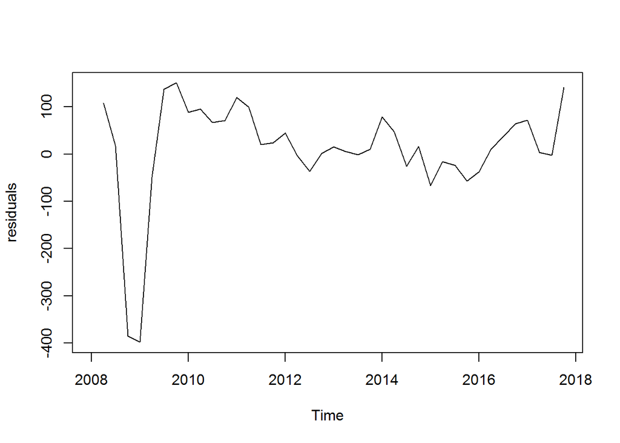

```r
plot(naive_ts$residuals, ylab = "residuals")
```

The residual plot pattern is almost similar to our timeseries plot. The graph decrease sharply and then rises again sharply and then follows a gradual rise and fall throught

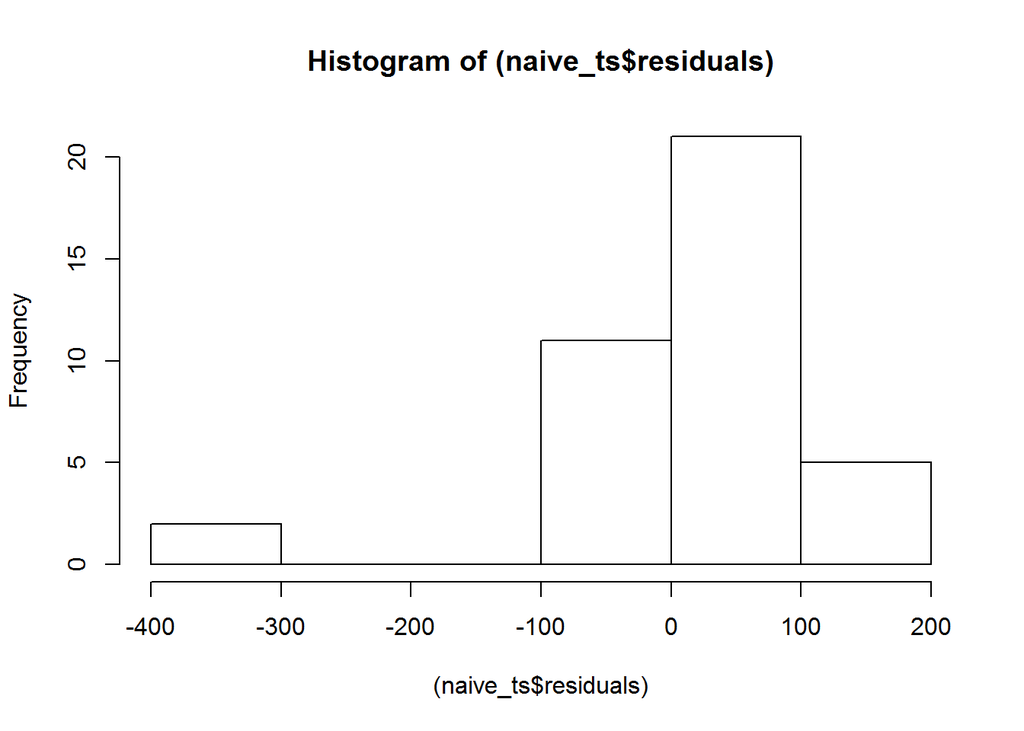

```r
hist((naive_ts$residuals))
```

The histogram plot appears highly left skewed and the gap in data is the sharp decline in the data.

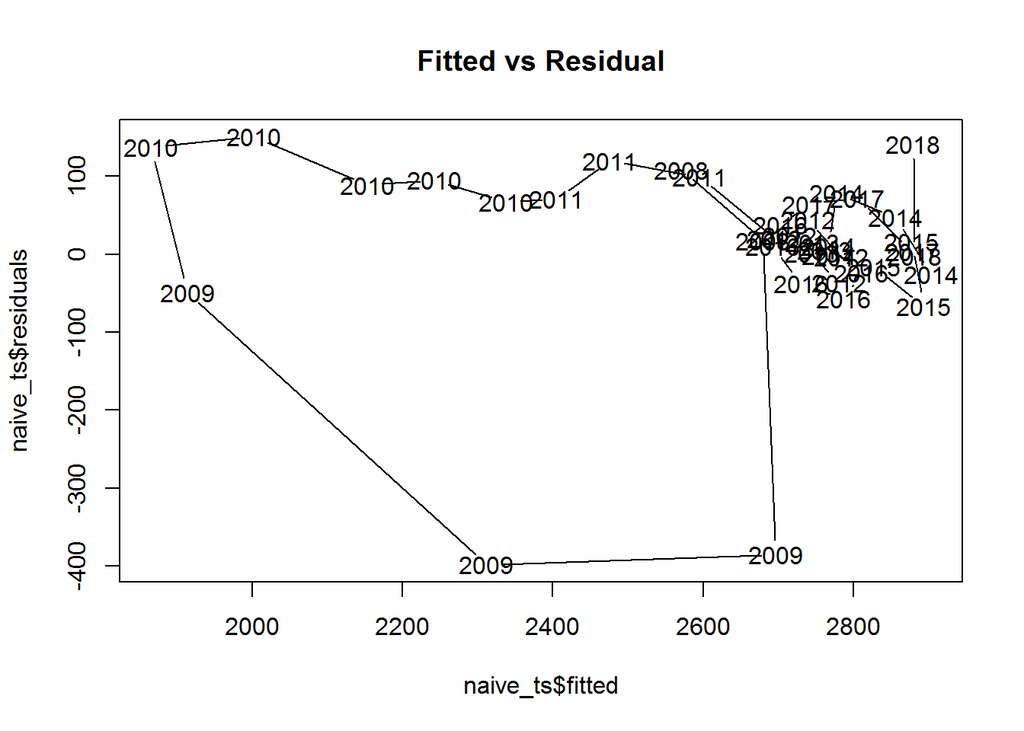

```r
plot(naive_ts$fitted, naive_ts$residuals, main="Fitted vs Residual",pch=19)
```

Fitted vs residual plots doesn’t appear to be linear or equally distributed. There are points which appear to be outliers. Also, it’s random with no pattern

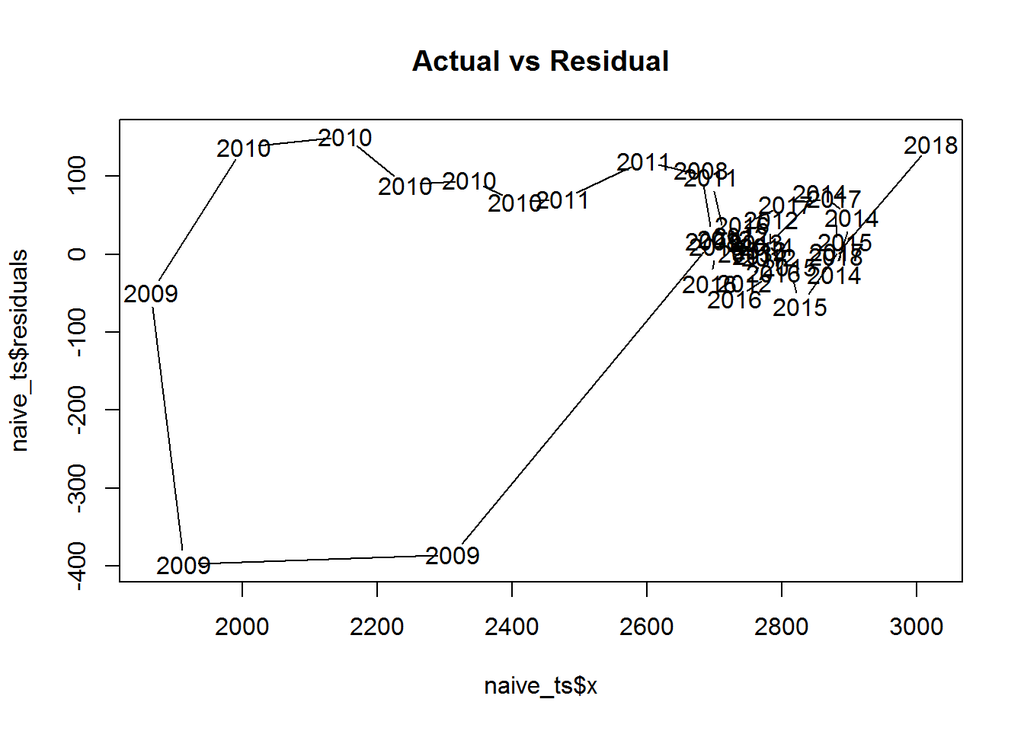

```r
#library(car)
#scatterplot(naive_ts$x~ naive_ts$residuals)
plot(naive_ts$x, naive_ts$residuals, main="Actual vs Residual")
```

Actual vs residual plots doesn’t appear to be linear and equally distributed. There are points which appear to be outliers. Also, there’s no pattern

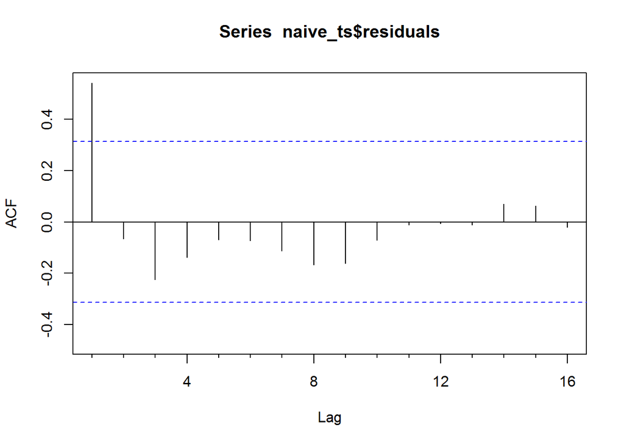

```r
Acf(naive_ts$residuals)
```

Acf plot indicates the presense of trend and only the starting point is above the significance. Rest are not

```r
accuracy(naive_ts)
```

```
##                    ME     RMSE      MAE       MPE     MAPE      MASE
## Training set 11.54359 109.7054 68.08205 0.2970542 2.852688 0.3286562
##                   ACF1
## Training set 0.5405785
```

```r
q <- forecast(naive_ts, h=4)
q
```

```
##         Point Forecast    Lo 80    Hi 80    Lo 95    Hi 95
## 2018 Q1         3021.6 2881.007 3162.193 2806.581 3236.619
## 2018 Q2         3021.6 2822.771 3220.429 2717.518 3325.682
## 2018 Q3         3021.6 2778.086 3265.114 2649.177 3394.023
## 2018 Q4         3021.6 2740.414 3302.786 2591.563 3451.637
```

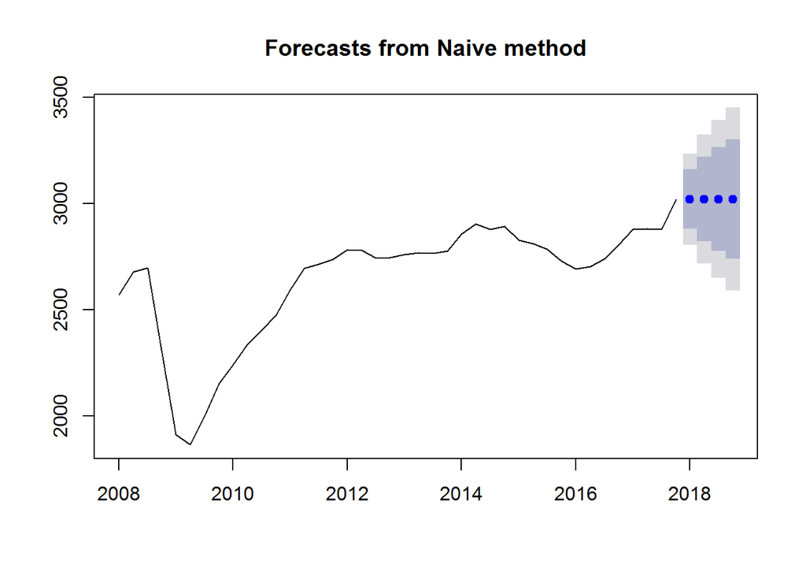

```r
plot(q)
```

**Using Simple Moving Averages** . Plot the graph for time series. . Show the Simple Moving average of order 3 on the plot above in Red . Show the Simple Moving average of order 6 on the plot above in Blue . Show the Simple Moving average of order 9 on the plot above in Green

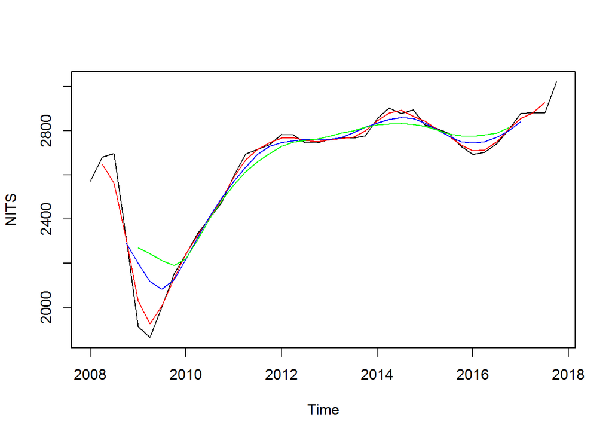

```r
plot(NITS)
ma_3 <- lines(ma(NITS,order=3),col ="red")
ma_6 <- lines(ma(NITS,order=6),col ="blue")
ma_9 <- lines(ma(NITS,order=9),col ="green")
```

Forecast of next 12 months using one of the simple average order that you feel works best for time series.

Forecasting the time series using m=3 because it fits the time series more accurately.

```r
ma_fore <- forecast(ma(NITS,3),h=4)
ma_fore
```

```
##         Point Forecast    Lo 80    Hi 80    Lo 95    Hi 95
## 2017 Q4       2975.052 2892.898 3057.206 2849.408 3100.695
## 2018 Q1       3022.173 2840.482 3203.863 2744.301 3300.045
## 2018 Q2       3069.293 2766.705 3371.882 2606.525 3532.062
## 2018 Q3       3116.414 2674.639 3558.189 2440.778 3792.051
```

```r
ma_fore <- forecast(ma(NITS,20),h=4)
```

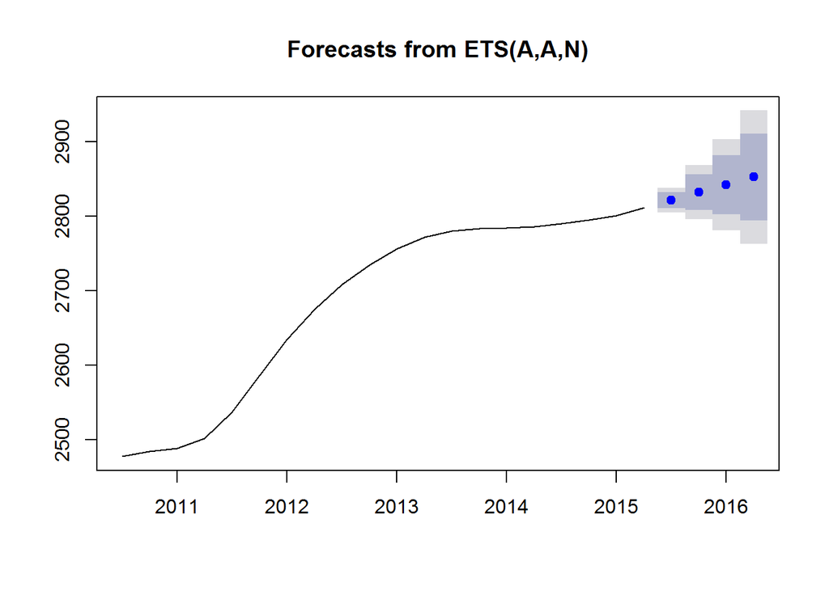

```r
plot(ma_fore)
```

**using Simple Smoothing model to forecast** . Perform a smoothing forecast for next 12 months for the time series. o What is the value of alpha? What does that value signify? o What is the value of initial state? o What is the value of sigma? What does the sigma signify?

```r
ets_forecast <- ets(NITS)
forecast_ets <- forecast.ets(ets_forecast, h=4)
summary(forecast_ets)
```

```
##
## Forecast method: ETS(A,N,N)
##
## Model Information:
## ETS(A,N,N)
##
## Call:
##  ets(y = NITS)
##
##   Smoothing parameters:
##     alpha = 0.9999
##
##   Initial states:
##     l = 2505.1655
##
##   sigma:  108.8364
##
##      AIC     AICc      BIC
## 528.7429 529.4095 533.8095
##
## Error measures:
##                   ME     RMSE      MAE       MPE     MAPE      MASE
## Training set 12.9118 108.8364 68.04088 0.3540331 2.845989 0.3284575
##                   ACF1
## Training set 0.5489618
##
## Forecasts:
##         Point Forecast    Lo 80    Hi 80    Lo 95    Hi 95
## 2018 Q1       3021.586 2882.106 3161.065 2808.270 3234.901
## 2018 Q2       3021.586 2824.342 3218.830 2719.927 3323.244
## 2018 Q3       3021.586 2780.016 3263.155 2652.137 3391.034
## 2018 Q4       3021.586 2742.648 3300.524 2594.987 3448.185
```

The value of Alpha sigma is 0.9999 The value of alpha signifies that higher weight is given to recent data. It is the choice of smoothing factor . If the value is very close to zero, it indicates that the forecasts are based on both recent and less recent observations. As seen from above, the value of alpha is 0.999 ,This value is very close to 1 which indicates that the most recent values have more weight

Value of initial state is 2505.16 As it increases, influence of forecast decreases

. Perform Residual Analysis for this technique. o Do a plot of residuals. What does the plot indicate?

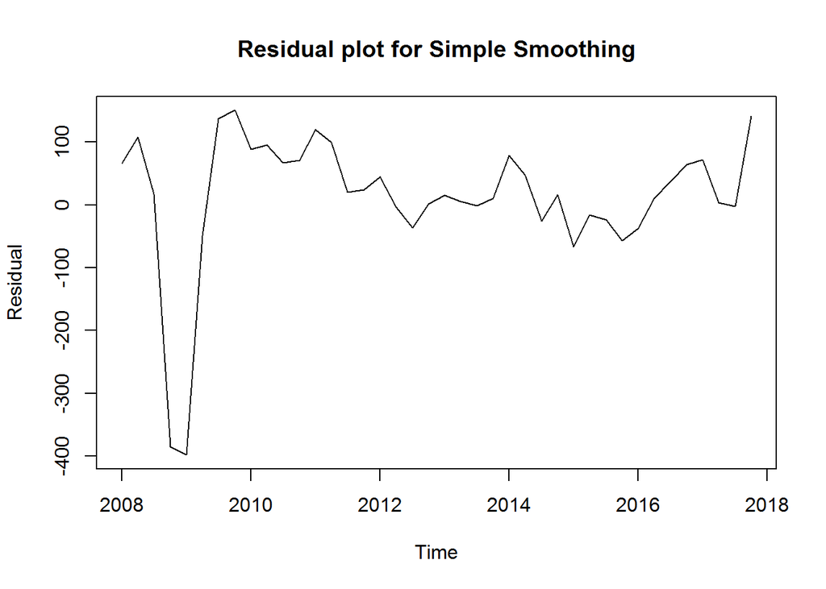

```r
plot(ets_forecast$residuals,main="Residual plot for Simple Smoothing",ylab="Residual")
```

The above shown is residual plot which is same like the time series graph . The graph is smooth time series. Residual component doesn’t has a high influence in time series

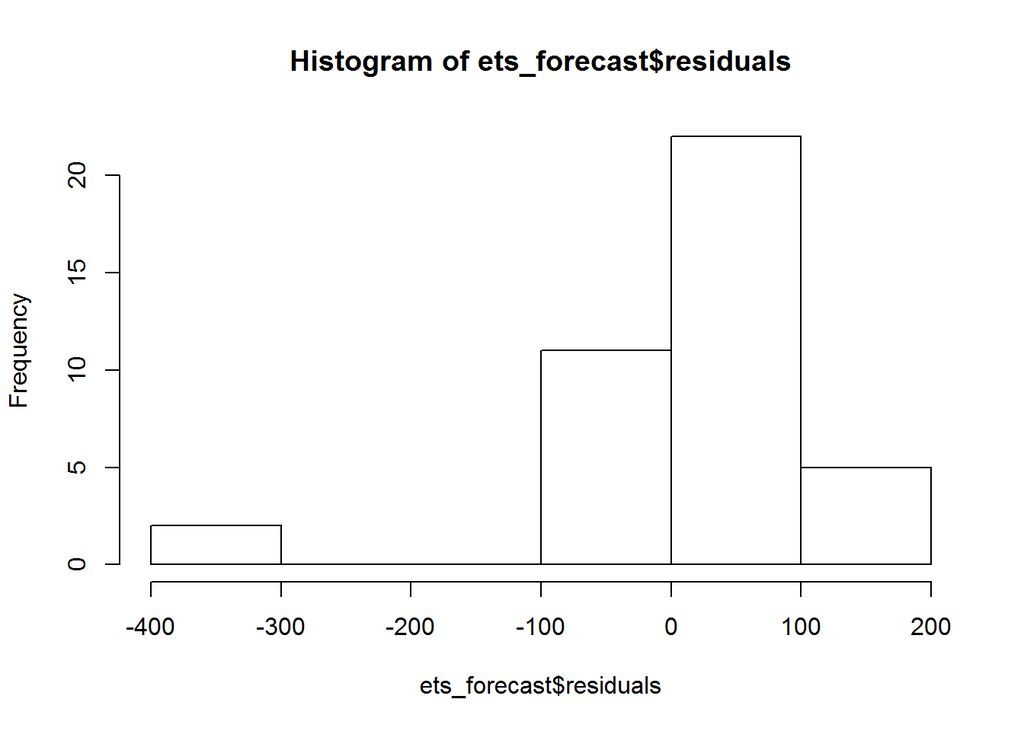

```r
hist(ets_forecast$residuals)
```

The histogram plot appears highly left skewed and the gap in data is the sharp decline in the data. Also, tthere is no pattern as such in the graph

o Do a plot of fitted values vs. residuals. What does the plot indicate?

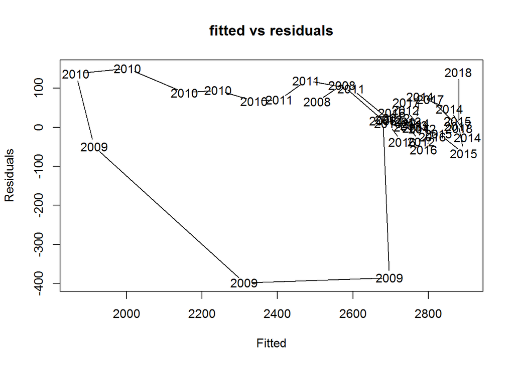

```r
plot(ets_forecast$fitted, ets_forecast$residuals, main = "fitted vs residuals" , xlab ="Fitted" , ylab = "Residuals")
```

Fitted vs residual plots doesn’t appear to be linear and equally distributed. There are points which appear to be outliers. Also, there’s no pattern

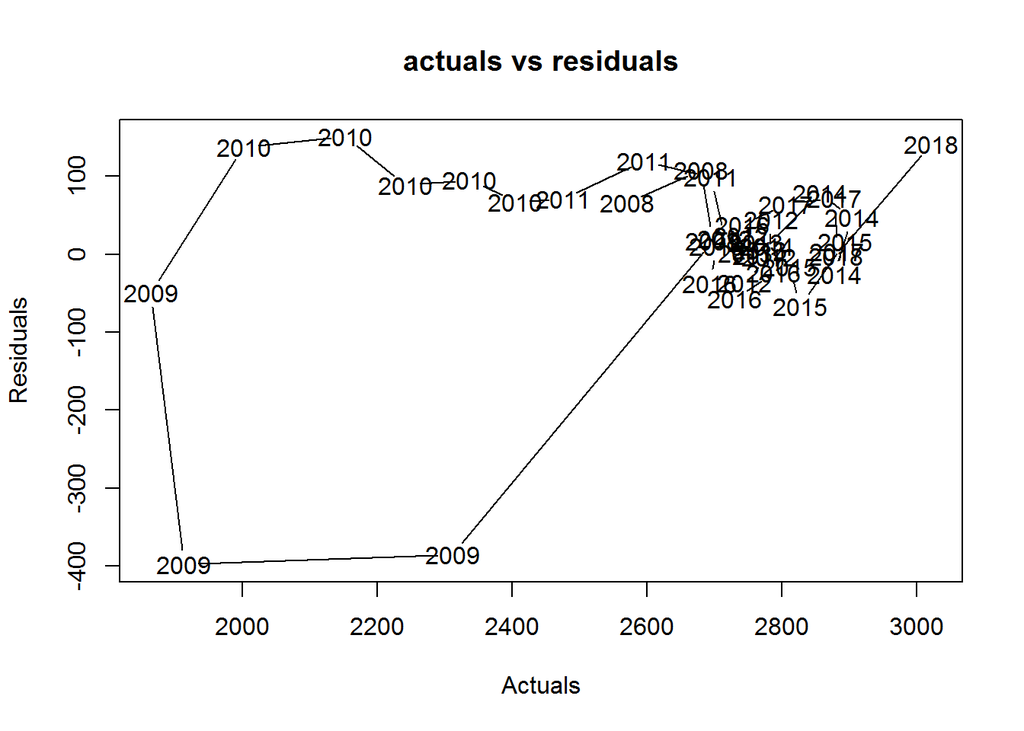

```r
plot(NITS, ets_forecast$residuals, main = "actuals vs residuals" , xlab ="Actuals" , ylab = "Residuals")
```

Actuals vs residual plots doesn’t appear to be linear and equally distributed. There are points which appear to be outliers. Also, there’s no pattern

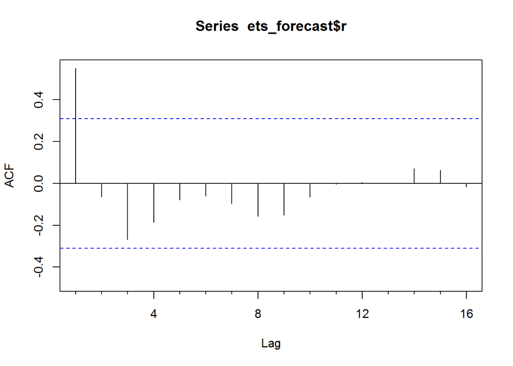

```r
Acf(ets_forecast$r)
```

Acf plot indicates the presense of trend and only the starting point is above the significance. Rest are not.

. Print the 5 measures of accuracy for this forecasting technique

```r
accuracy(ets_forecast)
```

```
##                   ME     RMSE      MAE       MPE     MAPE      MASE
## Training set 12.9118 108.8364 68.04088 0.3540331 2.845989 0.3284575
##                   ACF1
## Training set 0.5489618
```

. Forecast o Time series value for next year. Show table and plot

```r
q <- forecast(ets_forecast, h=4)
print(q)
```

```
##         Point Forecast    Lo 80    Hi 80    Lo 95    Hi 95
## 2018 Q1       3021.586 2882.106 3161.065 2808.270 3234.901
## 2018 Q2       3021.586 2824.342 3218.830 2719.927 3323.244
## 2018 Q3       3021.586 2780.016 3263.155 2652.137 3391.034
## 2018 Q4       3021.586 2742.648 3300.524 2594.987 3448.185
```

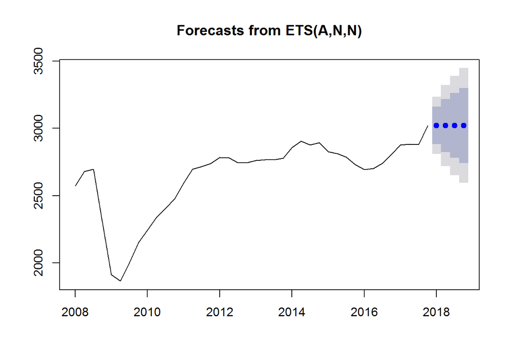

```r
plot(q)
```

**Holt-Winters** . Perform Holt-Winters forecast for next 12 months for the time series. o What is the value of alpha? What does that value signify? o What is the value of beta? What does that value signify? o What is the value of gamma? What does that value signify? o What is the value of initial states for the level, trend and seasonality? What do these values signify? o What is the value of sigma? What does the sigma signify?

```r
Price_Winters <- HoltWinters(NITS)
pf <- forecast(Price_Winters, h=4)
pf
```

```
##         Point Forecast    Lo 80    Hi 80    Lo 95    Hi 95
## 2018 Q1       3044.503 2776.792 3312.213 2635.075 3453.931
## 2018 Q2       3052.011 2696.923 3407.100 2508.950 3595.073
## 2018 Q3       3060.687 2615.999 3505.374 2380.596 3740.778
## 2018 Q4       3139.505 2601.904 3677.106 2317.315 3961.695
```

```r
summary(pf)
```

```
##
## Forecast method: HoltWinters
##
## Model Information:
## Holt-Winters exponential smoothing with trend and additive seasonal component.
##
## Call:
## HoltWinters(x = NITS)
##
## Smoothing parameters:
##  alpha: 0.7428379
##  beta : 0.1730485
##  gamma: 1
##
## Coefficients:
##          [,1]
## a  2904.32028
## b    29.47630
## s1  110.70636
## s2   88.73853
## s3   67.93749
## s4  117.27972
##
## Error measures:
##                   ME     RMSE      MAE     MPE     MAPE      MASE
## Training set 41.5499 210.1229 145.5452 1.67805 5.850816 0.7025981
##                   ACF1
## Training set 0.3363672
##
## Forecasts:
##         Point Forecast    Lo 80    Hi 80    Lo 95    Hi 95
## 2018 Q1       3044.503 2776.792 3312.213 2635.075 3453.931
## 2018 Q2       3052.011 2696.923 3407.100 2508.950 3595.073
## 2018 Q3       3060.687 2615.999 3505.374 2380.596 3740.778
## 2018 Q4       3139.505 2601.904 3677.106 2317.315 3961.695
```

. Perform Residual Analysis for this technique. o Do a plot of residuals. What does the plot indicate? o Do a Histogram plot of residuals. What does the plot indicate? o Do a plot of fitted values vs. residuals. What does the plot indicate? o Do a plot of actual values vs. residuals. What does the plot indicate? o Do an ACF plot of the residuals? What does this plot indicate?

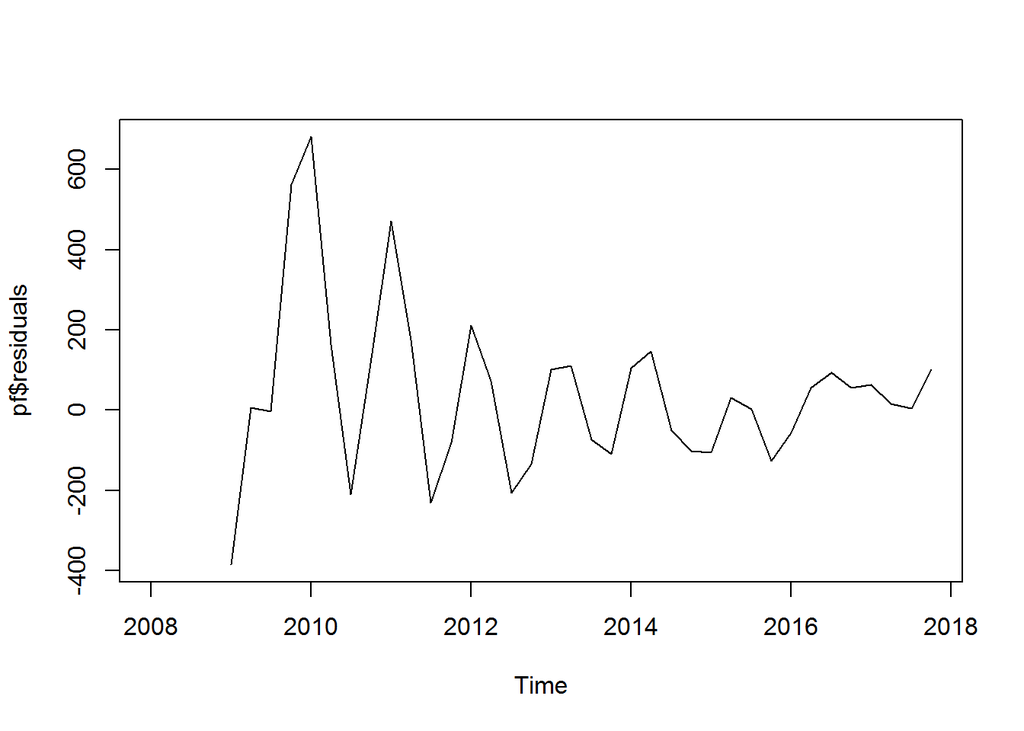

```r
plot(pf$residuals)
```

The residual plot looks very different when compared with other models. it indicates trend along and doesn’t match with the original time series graph.

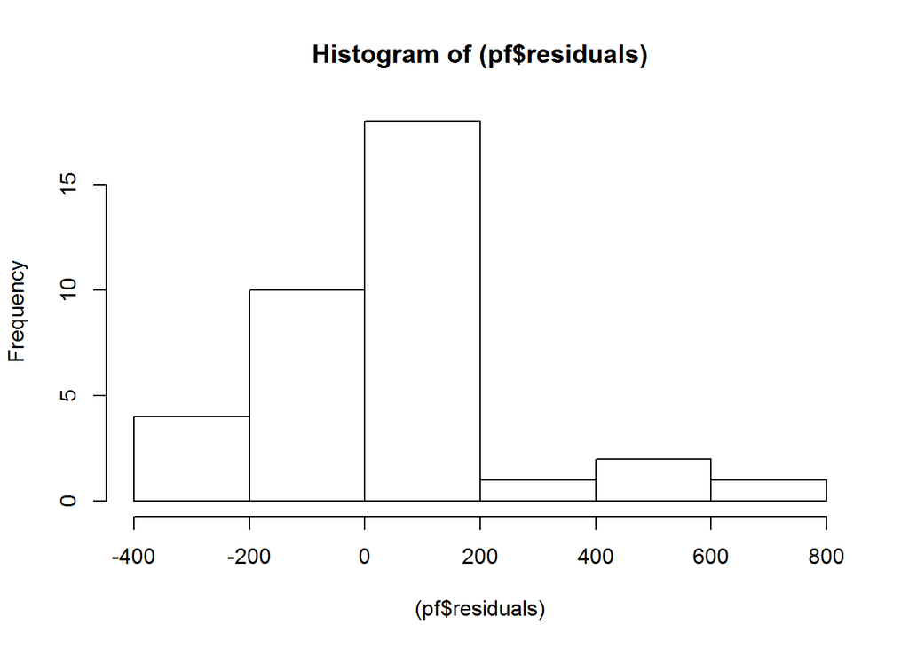

```r
hist((pf$residuals))
```

Histogram of the residuals also look different and appears rightly skewed ,while the other models looked left skewed.

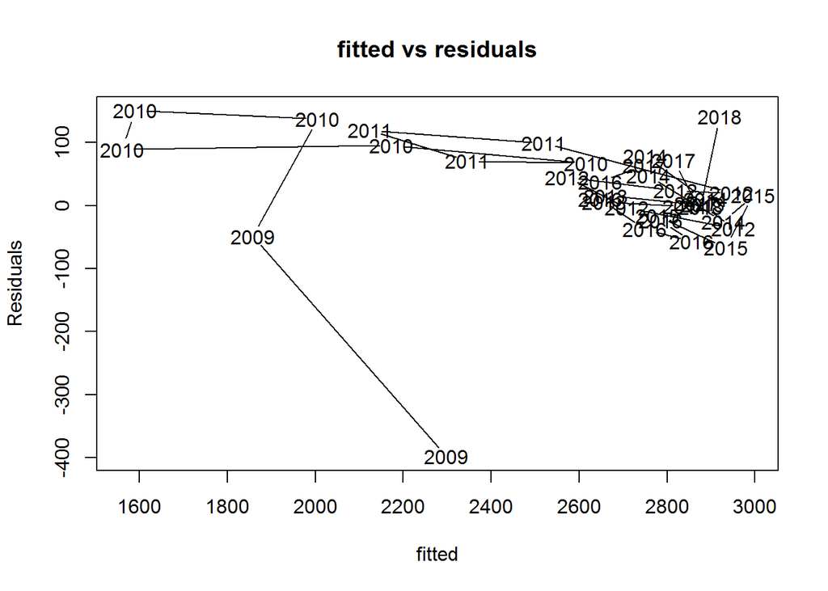

```r
plot(pf$fitted, ets_forecast$residuals, main = "fitted vs residuals" , xlab ="fitted" , ylab = "Residuals")
```

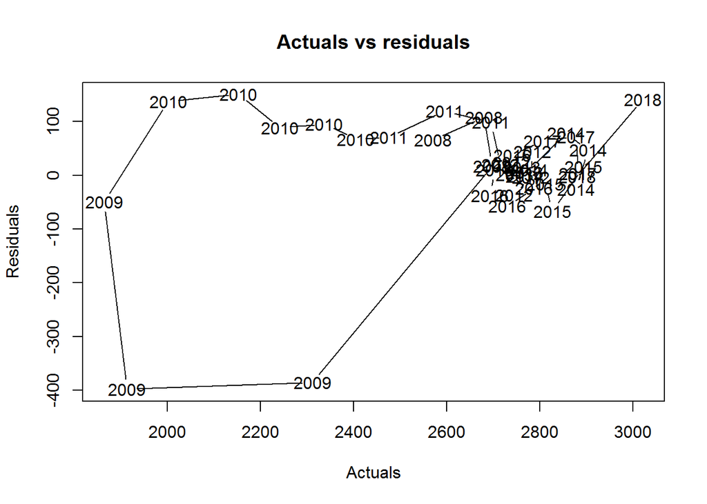

```r
plot(pf$x, ets_forecast$residuals, main = "Actuals vs residuals" , xlab ="Actuals" , ylab = "Residuals")
```

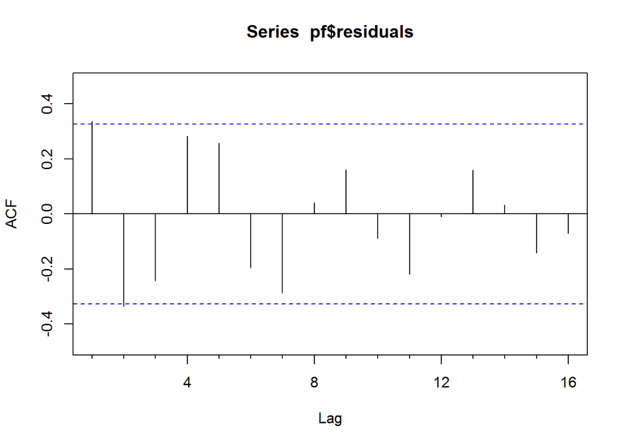

```r
Acf(pf$residuals)
```

Acf of the residuals seems to have only two significant points. All the other points are in it. There apears to be a trend.

**the 5 measures of accuracy for this forecasting technique**

```r
accuracy(pf)
```

```
##                   ME     RMSE      MAE     MPE     MAPE      MASE
## Training set 41.5499 210.1229 145.5452 1.67805 5.850816 0.7025981
##                   ACF1
## Training set 0.3363672
```

. Forecast o Time series value for next year. Show table and plot

```r
pf
```

```
##         Point Forecast    Lo 80    Hi 80    Lo 95    Hi 95
## 2018 Q1       3044.503 2776.792 3312.213 2635.075 3453.931
## 2018 Q2       3052.011 2696.923 3407.100 2508.950 3595.073
## 2018 Q3       3060.687 2615.999 3505.374 2380.596 3740.778
## 2018 Q4       3139.505 2601.904 3677.106 2317.315 3961.695
```

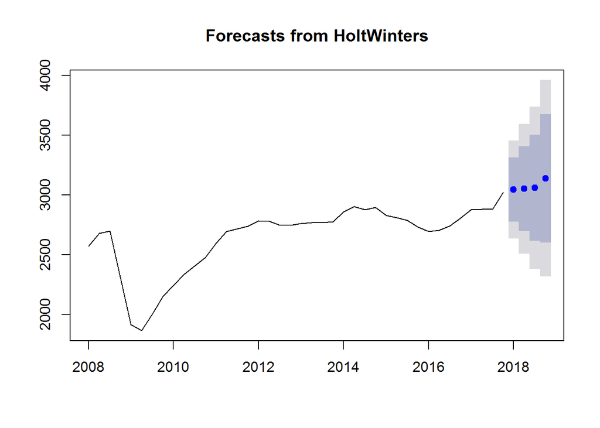

```r
plot(pf)
```

. Summarize this forecasting technique o How good is the accuracy? **Accuracy is bad since the value of MAPE is 5.85** o What does it predict the value of time series will be in one year? The predicted value will be between 2317.315 & 3961.695. Both in 2018 Q4, indicating that 2018Q4 me see the highest or lowest value.

**ARIMA or Box-Jenkins**

. Is Time Series data stationary? How did you verify? Please post the output from one of the test.